# 140.652 - Lab 9

# Welcome to 652

- If you are a new student to the series, approach me via email (mkaras2@jhu.edu) to get class Slack access
- Lecture: date and time as in 651, new zoom link
  - Time: Tuesdays, Thursdays 10:30 AM Eastern Time (US and Canada)
  - Join Zoom Meeting https://us02web.zoom.us/j/85176299997?pwd=QTRlYTJzZHRHRDROSG4rSTI0dzROdz09
- Lab: date and time and zoom link as in 651
  - Tuesday: 01:30 PM Eastern Time (US and Canada)
  - Tuesday: Join Zoom Meeting https://JHUBlueJays.zoom.us/j/92343078671?pwd=NlVBeWJwTGJjRDZlT3lsbk8wd0sxZz09
  - Wednesday: 09:30 AM Eastern Time (US and Canada)
  - Wednesday: Join Zoom Meeting https://JHUBlueJays.zoom.us/j/98279730728?pwd=
- TA OH: date and time and zoom link as in 651
  - Friday: 05:00 - 06:00 PM Eastern Time (US and Canada)
  - Join Zoom Meeting https://JHUBlueJays.zoom.us/j/93397501747?pwd=djN1citDSlRSREtyZjh3eEZacGdYZz09
- Homework
  - All homework has been posted on CoursePlus ahead of time with the expectation that problems are to be completed as the material is covered in lecture. (=> Work on Homework 4)
  - We encourage collaboration and discussions on homework solutions, but all turned-in solutions must be your own.

# HW4 Problem 1

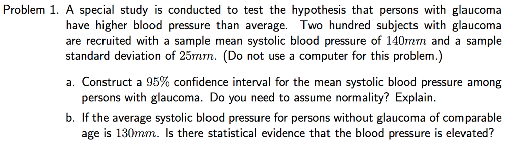

### (a)

- Recall: from CLT we know that the limit distribution of standarized sample mean
  $$Z _ { n } = \frac { \overline { X } _ { n } - \mu } { \sigma / \sqrt { n } }$$
  converges in distribution to
  $$Z \sim N ( 0,1 ).$$
- Note 1: Since we are working with a relatively large number of subjects ($n = 200$), it is reasonable to use Central Limit Theorem and build $95$% confidence interval for the mean $\mu$ parameter based on the limit normal distribution.
  - We do not have to assume normality of blood pressure in glaucoma patients then.
  - However, to invoke CLT, we need to assume independence of observations.
- Note 2: We do not know the $\sigma$ parameter true value. If the population standard deviation is unknown (which is often the case), then we use $s$, standard deviation of the sample, as the estimate of $\sigma$. Recall from Lecture 8: **Slutsky’s theorem** allows us to replace the unknown true population standard deviation $\sigma$ with estimator of standard deviation $s$

#### Slutsky’s theorem: review

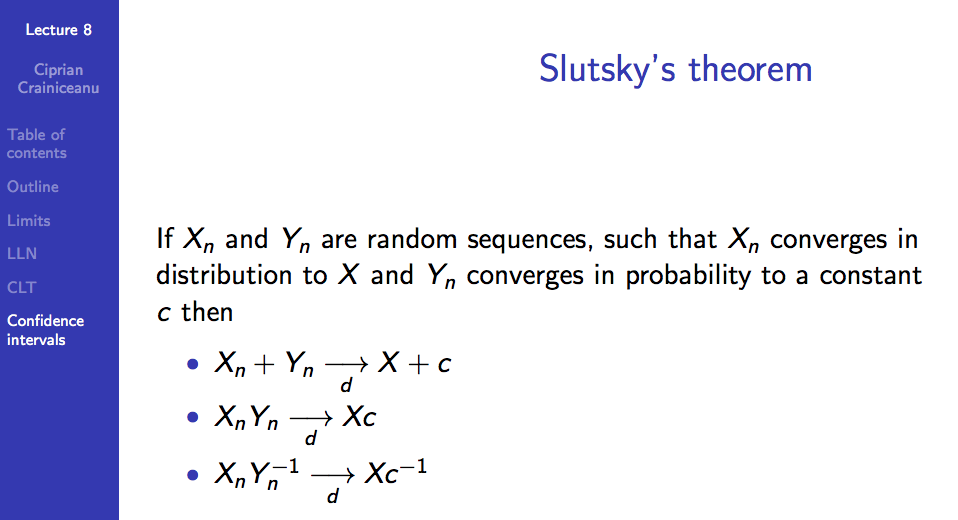

#### Slutsky’s theorem: application in our case

- From CLT, $Z _ { n }$ converges in distribution to $Z \sim N ( 0,1 )$:
  $$Z _ { n } = \frac { \overline { X } _ { n } - \mu } { \sigma / \sqrt { n } } \underset{d}{\to} N(0,1)$$
- $s$ sample estimator of standard deviation is a consistent estimator of true population standard deviation $\sigma$, that is, converges in probability to $\sigma$ ($\sigma$ is a constant):

$$s \underset{p}{\to} \sigma\;\;\; \text{ or equivalently: }\;\;\; \frac{\sigma}{s} \underset{p}{\to} 1$$

- We hence can invoke Slutsky’s theorem (second bullt point from the slide above) to say that:

$$\frac { \overline { X } _ { n } - \mu } { s / \sqrt { n } } = \frac { \overline { X } _ { n } - \mu } { \sigma / \sqrt { n } } \cdot \frac{\sigma}{s}\underset{d}{\to} N(0,1) \cdot 1 \equiv N(0,1)$$

#### Solution

- Using above (that is, approximation of $\frac { \overline { X } _ { n } - \mu } { s / \sqrt { n } }$ to standard normal distribution) we can write

$$\begin{split}
0.95 & \approx P\left(z_{0.025} \leq \frac { \overline { X } _ { n } - \mu } { s / \sqrt { n } } \leq z_{0.975} \right) \\
& = P\left(z_{0.025} \leq \frac{140 - \mu}{25/\sqrt{200}} \leq z_{0.975} \right) \\
& = P\left( -140 + z_{0.025}\frac{25}{\sqrt{200}} \leq -\mu \leq -140 + z_{0.975}\frac{25}{\sqrt{200}}\right) \\
& = P\left(140 - z_{0.025}\frac{25}{\sqrt{200}} \geq \mu \geq 140 - z_{0.975}\frac{25}{\sqrt{200}} \right) \\
& = P\left( 140 - z_{0.975}\frac{25}{\sqrt{200}} \leq \mu \leq 140 - z_{0.025}\frac{25}{\sqrt{200}} \right) \\
& = P\left(140 - z_{0.975}\frac{25}{\sqrt{200}} \leq \mu \leq 140 + z_{0.975}\frac{25}{\sqrt{200}} \right)
\end{split}$$

where the move from 2. to the end to the last line follows from the property of a quantiles of symmetric $0$-centered distributions: $z_q = - z_{1-q}$.

- Therefore, $95$% CI is of the form
  $$\left(140 - z_{0.975}\frac{25}{\sqrt{200}}, \; 140 + z_{0.975}\frac{25}{\sqrt{200}} \right) = (136.54, 143.46)$$

### (b)

- We want to test if the average systolic blood pressure (SBP) for persons with glaucoma is statistically different from the average SBP among persons without glaucoma (which is known to be $130$).
- To test this, we perform a **two-sided hypothesis test**. Note: A one-sided hypothesis test would be an acceptable homework answer. The two sided test is more conservative and typically chosen in a real-world setting (where we should not know the direction o the difference a priori).

We define $\mu_g$ as the mean SBP among persons with glaucoma and examine the null and alternative hypotheses:
$$\begin{aligned}
H_0: & \mu_g = 130 \text{ (meaning there is no difference)} \\
H_a: & \mu_g \neq 130 \text{ (meaning there is a difference)}
\end{aligned}$$

- That is, we want to **calculate the probability of observing a value as or more extreme than the observed one under the null hypothesis**.
- Distance between our observation ($\bar{X}=140$) and what is assumed under the null ($\mu_g = 130$) can be expressed as distance between the two: $|\bar{X} - \mu_g| = |140 - 130| = 10$.
- “Observing a value as or more extreme than the observed one under the null hypothesis” means observing distance as large, or larger: $|\bar{X} - \mu_g| \geq 10$.
- “Probability of observing a value as or more extreme than the observed one under the null hypothesis” means hence $P(|\bar{X} - \mu_g| \geq 10)$.
- Under the null hypothesis $\mu_g = 130$, hence, given $n=200$ is considered large enough,
  $$\frac{\bar{X}_n - \mu_g}{s/\sqrt{n}} \overset{CLT + Slutsky}{\approx} N(0,1)$$
- Denote $Z \sim N(0,1)$. We can write

$$\begin{align*}
P\left(\left|\bar{X} - \mu_g \right| \geq 10 \right)& =
P\left(\left|\frac{\bar{X} - \mu_g}{25/\sqrt{200}}\right| \geq \frac{10}{25/\sqrt{200}} \right) \\
& \overset{CLT + Slutsky}{\approx} \; P(|Z| \geq 5.66) \\
& = P(Z \leq -5.66) + P(Z \geq 5.66)
\end{align*}$$

```r
pnorm(-5.66) + (1 - pnorm(5.66))
```

```
## [1] 1.51373e-08
```

# HW4 Problem 2

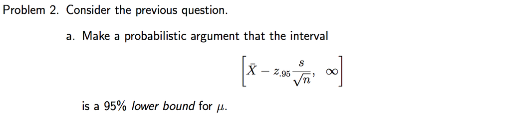

- Consider points (random variables) $A$, $B$ and an interval (random variable) $[A,B]$. $[A,B]$ is a two-sided 95% confidence interval for fixed, unknown parameter $\mu$ if

$$P\left( A \leq \mu \leq B \right) = 0.95.$$

- Consider a point (random variables) $A$ and an interval (random variable) $[A,\infty)$. $[A,\infty)$ is a one-sided 95% confidence interval for fixed, unknown parameter $\mu$ if

$$P\left( A \leq \mu \right) = 0.95.$$

Denote $Z \sim N(0,1)$. Using above notation, consider $A = \bar{X}-z_{.95} \frac{s}{\sqrt{n}}$. We have

$$\begin{split}
P\left(A \leq \mu \right)
& = P\left(\bar{X} - z_{.95} \frac{s}{\sqrt{n}} \leq \mu \right) \\
& = P\left(\bar{X} - \mu \leq z_{.95} \frac{s}{\sqrt{n}} \right) \\
& = P\left(\frac{\bar{X}-\mu}{s / \sqrt{n}} \leq z_{.95} \right) \\
& \approx_{CLT} P\left(Z \leq z_{.95} \right) \\
& = 0.95
\end{split}$$

# HW4 Problem 3

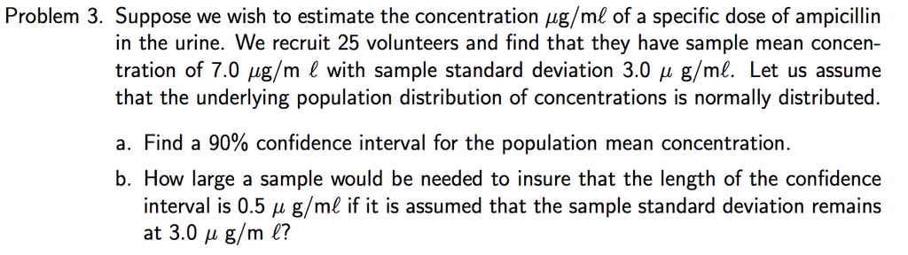

### (a)

- Recall from the Lecture 9 page 21:
  $$\frac { \overline { X }_n - \mu } { S / \sqrt { n } }$$
  follows Student’s $t$ distribution with $n-1$ degrees of freedom (no approximation here, this is the *exact* distributional result).
- Why not invoke Slutsky and use approx. normal distribution as we did in Problem 1 (where we invoked CLT + Slutsky)? Note that:
  - We know that when underlying distribution follows Normal distribution, $\frac { \overline { X }_n - \mu } { \sigma / \sqrt { n } } \sim N(0,1)$ for any $n$; hence **in particular** we could write that $\frac { \overline { X }_n - \mu } { \sigma / \sqrt { n } }$ converges in distribution to $N(0,1)$, that is, $\frac { \overline { X }_n - \mu } { \sigma / \sqrt { n } } \underset{d}{\to} N(0,1)$ (e.g. if we need this fact to invoke Slutsky’s theorem)
  - We know that $\frac{S}{\sigma} \underset{p}{\to} 1$
  - Hence we can use Slutsky and write a **limit distribution** as we did in Problem 1:

  $$\frac { \overline { X }_n - \mu } { s / \sqrt { n } } = \frac { \overline { X }_n - \mu } { \sigma / \sqrt { n } } \cdot \frac{s}{\sigma} \underset{d}{\to} N(0,1) \cdot 1 \equiv N(0,1)$$
  but be mindful this is a limit distribution and for $n$ as small as $n=25$ it is not plausible to assume the limit distribution holds (in our case, we are concerned as $\frac{s}{\sigma}$ may be not close to $1$ yet! Thus, we might be mis-estimating the true $\sigma$); hence we use **more conservative** $t$-distribution to describe distribution of $\frac { \overline { X }_n - \mu } { s / \sqrt { n } }$ and provide $90$% confidence interval for $\mu$:

$$\begin{aligned}
0.90 & = P\left(t_{24,0.05} \leq \frac{7 - \mu}{3/\sqrt{25}} \leq t_{24,0.95} \right) \\
& = P\left( -7 + t_{24,0.05}\frac{3}{\sqrt{25}} \leq -\mu \leq -7 + t_{24,0.95}\frac{3}{\sqrt{25}}\right) \\
& = P\left(7 - t_{24,0.05}\frac{3}{\sqrt{25}} \geq \mu \geq 7 - t_{24,0.95}\frac{3}{\sqrt{25}} \right) \\
& = P\left(7 - t_{24,0.95}\frac{3}{\sqrt{25}} \leq \mu \leq 7 - t_{24,0.05}\frac{3}{\sqrt{25}} \right) \\
& = P\left(7 - t_{24,0.95}\frac{3}{\sqrt{25}} \leq \mu \leq 7 + t_{24,0.95}\frac{3}{\sqrt{25}} \right)
\end{aligned}$$
where the move from 2. to the end to the last line follows from the property of a quantiles of symmetric $0$-centered distributions: $t_{\text{df};q} = - t_{\text{df};1-q}$.

- Hence CI is of the form

$$\left(7 - t_{24,0.95}\frac{3}{\sqrt{25}} , 7 + t_{24,0.95}\frac{3}{\sqrt{25}} \right)$$

```r
tstat <- qt(0.95, df = 24) * 3 / sqrt(25)
(CI <- 7 + c(-1,1) * tstat)
```

```
## [1] 5.973471 8.026529
```

```r
(diff(CI)) # CI width
```

```
## [1] 2.053058
```

- A 90% confidence interval for mean concentration of ampicillin among subjects on this particular dosage is $\left(5.97, 8.03 \right)$.
- Why we need to consider $t$-distribution instead of invoking CLT + Slutsky’s as in Problem 1? (Hint: consider sample size in this problem!)

### (b)

- The current confidence interval length is $2.05$. To have it equal $0.5$, from the $CI$ formulation in last line of (a) we see that it narrows down to solving

$$\begin{aligned}
2 \cdot t_{n-1,0.95} \cdot \frac{3}{\sqrt{n}} & \overset{set}{=} 0.5 \\
t_{n-1,0.95} \cdot \frac{3}{\sqrt{n}} & = 0.25
\end{aligned}$$

for some new $n$.

- But solving that is not simple as $t_{n-1,0.95}$ involves $n$ as well. We can, however, assume approximation of the $t$-student distribution for some updated (surely larger) $n$ with the normal distribution; that is, solve with $z_{0.95}$ instead of $t_{n-1,0.95}$ to start with, and see if obtained $n$ works for $t$-distribution same well.
  $$\begin{aligned}
  z_{0.95}\frac{3}{\sqrt{n}} & \overset{set}{=} 0.25\\
  \sqrt{n} & = 12 \cdot z_{0.95} \\
  \sqrt{n} & = 19.73824 \\
  n & = 389.5981 \approx 390
  \end{aligned}$$

```r
n <- 390
Zstat <- qnorm(0.95) * 3/sqrt(n)
CI <- 7 + c(-1,1)*Zstat
(diff(CI))
```

```
## [1] 0.4997424
```

so indeed we see it is **just less than $0.5$** - great!

- We use $n = 390$ and check if this $n$ yields desired CI width when we use $t$-distribution. We again use CI formula as derived in (a), $\left(7 - t_{n-1,0.95}\frac{3}{\sqrt{n}} , 7 + t_{n-1,0.95}\frac{3}{\sqrt{n}} \right)$. We have

```r
n <- 390
tstat <- qt(0.95, df = n-1) * 3 / sqrt(n)
CI <- 7 + c(-1,1) * tstat
(diff(CI))
```

```
## [1] 0.5009354
```

we see it is **not** less than $0.5$. Let’s try with a sample larger by 1, then 2, then 3… elements.

```r
n <- 391
tstat <- qt(0.95, df = n-1) * 3 / sqrt(n)
CI <- 7 + c(-1,1) * tstat
(diff(CI))
```

```
## [1] 0.5002913
```

```r
n <- 392
tstat <- qt(0.95, df = n-1) * 3 / sqrt(n)
CI <- 7 + c(-1,1) * tstat
(diff(CI))
```

```
## [1] 0.4996497
```

it is **just less than $0.5$** - great! Hence the answer is if we use the $t$-distribution, we require a sample size of $392$.

#### Alternative solution

```r
n <- 25
while (TRUE){
  tstat <- qt(0.95, df = n-1) * 3 / sqrt(n)
  CI <- 7 + c(-1,1) * tstat
  CI.length <- diff(CI)
  if(CI.length < 0.5){
    break
  } else {
   n <- n + 1
  }
}
print(n)
```

```
## [1] 392
```